# ECVP 2026 poster panel builder

From similarity structure to gaze dynamics

Josef Mana, Jiri Lukavsky, Ivana Kapounova, Filip Dechterenko

2026-08-20

> **This document is a code base** for the ECVP 2026 poster *From similarity structure to gaze dynamics: Eye-movement signatures of decision difficulty in a triplet matching task*. It contains all R code used to generate panel plots presented in the poster, in their final form.

# 0 · Setup

## Packages

```r
# Data wrangling and visualisation
library(dplyr)
library(tidyr)
library(ggplot2)
library(purrr)
library(stringr)
library(gt)
library(patchwork)

# Statistics
library(lme4) |>
  suppressPackageStartupMessages()

# Eye-tracking engines
library(mathpsychr)

# Project-specific
library(tripletviewing)
```

## Constants

```r
# NOTE: This chunk defines constants for poster printing, including output
# directory, colour palette and size scaling constants.

# TRUE strips every FACES photograph from the build. Set on the command line,
# never here. Set to FALSE to reproduce the poster panel one exactly:
#
#   rmarkdown::render(<this file>, params = list(public = FALSE), ...)
#
# `exists()` is there to guard the file still runs when sourced outside knitr.
PUBLIC_BUILD <- exists("params", inherits = TRUE) && isTRUE(params$public)

# Output directory
OUT_DIR <- here::here("outputs", "2026-ecvp-poster", "panels")

# Output geometry
PANEL_H_MM    <- 290
ASPECT_RESULT <- 895.5 / 683.6  # 1.3100  the four result slots
ASPECT_TASK   <- 712.6 / 681.6  # 1.0455  narrower: the two-study pipeline sits beside it in that block

# --- Text ----
# Native to macOS, Keynote and every R graphics device
FIG_FONT <- "Helvetica Neue"
FIG_BASE <- 11 # theme_set(poster_theme(base_size = 22)) at export

# At the export size every hardcoded annotation renders at roughly half its
# apparent preview size. Multiply every one of them by ANN to ensure proper size
# on export.
ANN <- 2

# Linewidths are manipulated separately from ANN.
LWD <- ANN

# ---- Palette ----
navy    <- "#274B6D"
navy_2  <- "#5A87AC"
navy_1  <- "#A9C4DA"
ochre   <- "#A85F1B"
ochre_l <- "#F2C078"
slate   <- "#51708C"
dim_    <- "#7E9AB5"
hair    <- "#C6D4E1"
tint    <- "#EAF0F5"

# One convention for reference lines
COL_NULL   <- slate # chance / zero / identity
COL_ACCENT <- ochre # the highlighted finding, e.g. the baseline bracket
COL_RULE   <- hair  # faint structure, e.g. the coverage strip

# ---- ordered agreement bins ----
# NOTE: the NAMES are load-bearing, they must keep matching the levels that
# append_majority_coding() produces. Only the values can change here.
bin_pal <- c(
  "50-65% (Low)"    = navy_1,
  "65-85% (Medium)" = navy_2,
  "85-100% (High)"  = navy
)

# "50-65% (Low)" -> "Low", ...
short_bin <- \(x) str_extract(x, "(?<=\\()[^)]+(?=\\))")

# ---- nominal chosen vs unchosen ----
# Conservative alternative: c(Chosen = navy, Unchosen = navy_2)
ref_pal <- c(
  Chosen   = navy_2,
  Unchosen = ochre
)

# ---- AOIs ----
aoi_cols <- c(
  query = ochre,
  left  = navy,
  right = navy_2
)

# ---- Prediction modelling ----
# Model family. "All four" takes the accent because it is the estimate the
# panel adjudicates on. Alone and Paired are the comparison it is made against.
model_pal <- c(
  Alone      = "#9DB6CC",
  Paired     = slate,
  `All four` = COL_ACCENT
)

# Filled glyphs only. Open shapes on the lighter tones were the original
# problem: doubly faint exactly where the panel is weakest.
model_shape <- c(
  Alone      = 15,  # square
  Paired     = 17,  # triangle
  `All four` = 16   # circle
)
```

## Theme

```r
# A0 via theme_set(poster_theme(base_size = 22)).
poster_theme <- function(base_size = FIG_BASE, base_family = FIG_FONT) {
  theme_classic(
    base_size = base_size,
    base_family = base_family
  ) +
    theme(
      plot.background = element_rect(fill = "white", colour = NA),
      legend.position = "right",
      legend.background = element_rect(
        fill = "white",
        colour = hair,
        linewidth = 0.4
      ),
      legend.key = element_blank(),
      legend.text = element_text(size = rel(0.9)),
      legend.spacing.y = unit(2, "pt"),
      strip.text = element_text(
        face = "bold",
        hjust = 0.5,
        margin = margin(0.3 * base_size, 0.3 * base_size, 0.3 * base_size, 0.3 * base_size)
      ),
      strip.background = element_rect(fill = "grey92", colour = "grey75", linewidth = 0.4 * LWD),
      axis.title = element_text(face = "bold"),
      plot.title.position = "plot",
      plot.caption.position = "plot",
      plot.title = ggtext::element_textbox_simple(
        family = base_family,
        face = "bold",
        halign = 0.5,
        size = rel(1.15),
        margin = margin(b = 0.4 * base_size)
      ),
      plot.subtitle = ggtext::element_textbox_simple(
        family = base_family,
        colour = "grey30",
        halign = 0.5,
        size = rel(1.00),
        margin = margin(b = 0.6 * base_size)
      ),
      plot.caption = ggtext::element_textbox_simple(
        family = base_family,
        colour = "grey45",
        halign = 0,
        size = rel(0.80),
        margin = margin(t = 0.6 * base_size),
        lineheight = 1.15
      )
    )
}

theme_set(poster_theme())
```

## Helpers

```r
# Tier 1 (title)    = the claim, in words
# Tier 2 (subtitle) = the number that backs it
# Tier 3 (caption)  = how to read the graphic
panel_text <- function(claim = NULL, number = NULL, how = NULL) {
  labs(title = claim, subtitle = number, caption = how)
}

# Title and subtitle are NULLed explicitly, so this can be applied on top of an
# existing panel_text() without leaving a stale tier behind.
poster_text <- function(finding, how = NULL) {
  labs(
    title    = NULL,
    subtitle = NULL,
    caption  = paste(finding, how)
  )
}

# Caption for patchwork.
poster_caption <- function(finding, how = NULL) {
  plot_annotation(
    caption = paste(finding, how)
  )
}

# Bounded statistics, APA-style: leading zero stripped, symbol italic.
no0 <- function(x, digits = 2) {
  sub("^(-?)0\\.", "\\1.", sprintf(paste0("%.", digits, "f"), x))
}

# Format Peason's correlation
fmt_r <- function(ct) {
  sprintf(
    "*r* = %s [%s, %s]",
    no0(ct$estimate),
    no0(ct$conf.int[1]),
    no0(ct$conf.int[2])
  )
}
```

## Data

### Import

```r
# NOTE: raw data used in this report are available via the {tripletviewing} package.
data(decisionprocessdata) # eye-tracking study, N = 51, EyeLink
data(preferencedata)      # online study, N = 98, jsPsych
data(tripletcodes)        # triplet id -> stimulus code lookup
```

### Pre-processing

```r
# Shared difficulty/agreement rate binning
bin_breaks <- c(0, 0.65, 0.85, 1)
bin_labels <- c("Low", "Medium", "High")

# Helper function for data pre-processing
code_study <- function(data, experiment, include_blocks) {
  data |>
    tripletviewing::append_majority_coding(
      id_col = "id",
      include_blocks = include_blocks,
      # NOTE: preferencedata already has catch trials removed upstream
      # (see ?preferencedata) so this is a no-op for them. It is passed
      # anyway so that both studies go through an identical code path.
      exclude_catches = TRUE,
      difficulty_bins = bin_breaks,
      difficulty_labels = bin_labels
    ) |>
    mutate(
      experiment = experiment,
      id = as.character(id)
    )
}

# ── (a) Difficulty structure: blocks 1-5 only ─────────────────────────────────
# The canonical agreement rates and bins. Used for everything that involves
# difficulty, including the whole eye-tracking pipeline.
difficulty_data <- bind_rows(
  code_study(preferencedata$data, "online", 1:5),
  code_study(decisionprocessdata$data, "eyetracking", 1:5)
)

# ── (b) Reliability checks: all blocks ────────────────────────────────────────
# Used ONLY by §3.3 and §3.4, which need blocks 6-7 present, but read only
# `response_std`, `response_left`, `block` and `tid`, never the bins. The bin
# columns are dropped to prevent using this version elsewhere by accident.
all_response_data <-
  bind_rows(
    code_study(preferencedata$data, "online", 1:7),
    code_study(decisionprocessdata$data, "eyetracking", 1:7)
  ) |>
  select(-tno, -agreement_rate, -agreement_bin)
```

### Response data

```r
# ---- Basic data ----
rv <-
  difficulty_data |>
  group_by(experiment, tid) |>
  summarise(
    m = mean(response_std),
    s = sd(response_std),
    sem = s / sqrt(n()),
    .groups = "drop"
  ) |>
  group_by(experiment) |>
  mutate(rank = rank(m) / n()) |>
  ungroup()

# ---- Agreement across studies (`p_cross`) data ----
rvw <-
  rv |>
  pivot_wider(
    names_from = experiment,
    values_from = c(m, s, sem, rank),
    id_cols = tid
  ) |>
  drop_na()

# ---- Side invariance data ----
rrw <-
  all_response_data |>
  mutate(reversed = response_std == response_left) |> # Return it back
  group_by(tid, reversed, experiment) |>
  summarise(
    m = mean(response_std),
    sem = sd(response_std) / sqrt(n()),
    .groups = "drop"
  ) |>
  pivot_wider(
    names_from = reversed,
    values_from = c(m, sem),
    id_cols = c(tid, experiment)
  )

# ---- Time stability data ----
dss <-
  all_response_data |>
  filter(block %in% c(1, 6)) |>
  group_by(experiment, block, tid) |>
  summarise(
    m = mean(response_std),
    sem = sd(response_std) / sqrt(n()),
    .groups = "drop"
  ) |>
  pivot_wider(
    id_cols = c(tid, experiment),
    names_from = block,
    values_from = c(m, sem)
  )
```

# 1 · The task (row 1, column 2)

> **What the participant saw.** On each trial a **query** face sits above two **reference** faces. The task is to choose the reference more similar to the query. The task thus constitutes a *triplet matching* task, the standard probe for recovering perceptual similarity spaces.

All three faces are drawn from the FACES database, matched within a triplet for age group and sex and differing in emotional display. The three **areas of interest** (AOIs) define the coordinate frame for every gaze measure used in Sections 4 through 6.

Left–right reference position was randomised per participant, so “left” and “right” carry no stimulus identity. The arrow in the panel marks that swap.

## 1.1 Screen layout

```r
# NOTE: downstream eye-tracking analysis takes in this data frame containing
# screen layout used during the experiment.
layout <- data.frame(
  aoi = c("query", "left", "right"),
  x = c(840, 665, 1015), # horizontal centre, px
  y = c(313, 616, 616),  # vertical centre, px
  w = 200,               # width, px
  h = 250                # height, px
)
```

## 1.2 Poster panel

```r
# Helper function for loading faces, build according to
# tripletviewing::plot_triplet()
load_face <- function(code, path) {
  file <- if (stringr::str_detect(code, "\\.jpg$")) code else paste0(code, ".jpg")
  grDevices::as.raster(imager::load.image(file.path(path, file)))
}
```

```r
faces_dir <- here::here("data-raw", "FACES-small")

n_triplets_task <- dplyr::n_distinct(difficulty_data$tid)
n_blocks_task <- dplyr::n_distinct(difficulty_data$block)

trials_pp_task <-
  difficulty_data |>
  filter(experiment == "eyetracking") |>
  count(id, name = "n") |>
  pull(n) |>
  median() |>
  round()

# NOTE: use only pictures allowed to be shared in this way via the FACES
# Platform Release Agreement, which reads:
#
# 6. Objects available via the FACES platform are neither permitted for
#    publication in any type of report, paper, and other document nor
#    permitted for display in any type of presentation or exhibition.
# 7. Exempt from rule 6 are objects (photographs and videos) based on pictures
#    of the following persons: 004, 066, 079, 116, 140, and 168.
#    Research-related publication and display of the corresponding
#    photographs/videos are permitted for the purpose of illustrating research
#    methodology. These photographs/videos must not be published or displayed
#    for any other purpose. All other rules fully apply to this subset of
#   objects as well.
example_triplet <- tibble::tribble(
    ~query, ~ref_left, ~ref_right,
    "004_o_m_a_a", "066_y_m_n_a", "116_m_m_d_a"
)

aoi_boxes <-
  layout |>
  mutate(
    xmin = x - w / 2,
    xmax = x + w / 2,
    ymin = y - h / 2,
    ymax = y + h / 2,
    code = c(
      query = example_triplet$query,
      left  = example_triplet$ref_left,
      right = example_triplet$ref_right
    )[aoi],
    label = c(
      query = "query",
      left  = "left (A/B)",
      right = "right (B/A)"
    )[aoi],
    # Labels sit outside the boxes: query above, references below.
    label_y = if_else(aoi == "query", ymin - 25, ymax + 45),
    aoi = factor(aoi, levels = c("query", "left", "right"))
  )

# Display-only crop of the screen
TASK_VIEW_ASPECT <- 1.25  # width / height of the plot region, caption excluded
TASK_VIEW_PAD    <- 10L   # screen px of clear space around the labelled stimuli
TASK_LABEL_H     <- 60L   # screen px a label line occupies

task_ink_x <- c(min(aoi_boxes$xmin), max(aoi_boxes$xmax))
task_ink_y <- c(
  min(c(aoi_boxes$ymin, aoi_boxes$label_y - TASK_LABEL_H / 2)),
  max(c(aoi_boxes$ymax, aoi_boxes$label_y + TASK_LABEL_H / 2))
)

view_h <- diff(task_ink_y) + 2 * TASK_VIEW_PAD
view_w <- max(diff(task_ink_x) + 2 * TASK_VIEW_PAD, view_h * TASK_VIEW_ASPECT)

view <- list(
  xmin = mean(task_ink_x) - view_w / 2,
  xmax = mean(task_ink_x) + view_w / 2,
  ymin = mean(task_ink_y) - view_h / 2,
  ymax = mean(task_ink_y) + view_h / 2
)

inset  <- 0.010 * view_w
screen <- list(
  xmin = view$xmin + inset, xmax = view$xmax - inset,
  ymin = view$ymin + inset, ymax = view$ymax - inset
)

# Reported in the caption, so the figure states its own crop.
task_crop_pct <- c(
  x = 100 * (view$xmax - view$xmin) / 1680,
  y = 100 * (view$ymax - view$ymin) / 1050
)

# NOTE: There are two ways for the faces to be absent:
#  - the files are genuinely missing, or
#  - this is the public build and they must not be presented.
faces_available <-
  !PUBLIC_BUILD &&
  all(file.exists(file.path(faces_dir, paste0(aoi_boxes$code, ".jpg"))))

face_layers <-
  if (faces_available) {
    purrr::pmap(
      list(aoi_boxes$code, aoi_boxes$xmin, aoi_boxes$xmax, aoi_boxes$ymin, aoi_boxes$ymax),
      \(code, x0, x1, y0, y1) annotation_raster(
        load_face(code, faces_dir),
        xmin = x0, xmax = x1, ymin = y0, ymax = y1,
        interpolate = TRUE
      )
    )
  } else {
    list()
  }
```

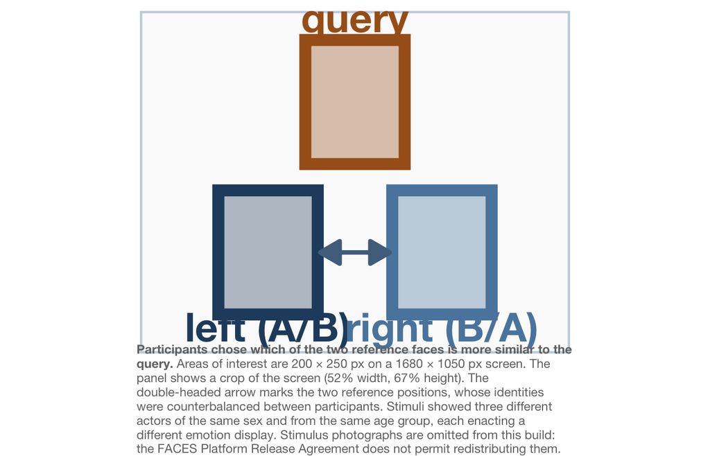

```r
# ---- Poster caption ----
task_finding <-
  "**Participants chose which of the two reference faces is more similar to the query.**"
task_how <- paste(
  "Areas of interest are 200 × 250 px on a 1680 × 1050 px screen.",
  sprintf(
    "The panel shows a crop of the screen (%.0f%% width, %.0f%% height).",
    task_crop_pct[["x"]],
    task_crop_pct[["y"]]
  ),
  "The double-headed arrow marks the two reference positions, whose identities",
  "were counterbalanced between participants. Stimuli showed three different",
  "actors of the same sex and from the same age group, each enacting a different",
  "emotion display.",
  if (faces_available) {
    paste(
      "Depicted stimuli are illustrative, based on the FACES database",
      "(faces.mpdl.mpg.de) and shown under the FACES Platform Release Agreement."
    )
  } else {
    paste(
      "Stimulus photographs are omitted from this build: the FACES Platform",
      "Release Agreement does not permit redistributing them. The coloured boxes",
      "mark where the faces appeared."
    )
  }
)

# ---- Poster plot ----
p_r1c2_task <-
  aoi_boxes |>
  ggplot() +
  ## ---- 1. The screen (cropped) ----
  annotate(
    "rect",
    xmin = screen$xmin,
    xmax = screen$xmax,
    ymin = screen$ymin,
    ymax = screen$ymax,
    fill = "grey98",
    colour = hair,
    linewidth = 0.4 * LWD
  ) +
  ## ---- 2. Stimuli at true screen coordinates ----
  face_layers +
  ## ---- 3. The AOIs ----
  geom_rect(
    aes(
      xmin = xmin,
      xmax = xmax,
      ymin = ymin,
      ymax = ymax,
      fill = aoi,
      colour = aoi
    ),
    alpha = if (faces_available) 0 else 0.35,
    linewidth = 2 * LWD
  ) +
  ## ---- 4. Labels, outside the boxes ----
  geom_text(
    aes(
      x = x,
      y = label_y,
      label = label,
      colour = aoi
    ),
    size = 5 * ANN,
    fontface = "bold",
    vjust = 0.15,
    show.legend = FALSE
  ) +
  ## ---- 5. Counterbalancing ----
  annotate(
    "segment",
    x    = 770,
    xend = 910,
    y    = 616,
    yend = 616,
    colour = slate,
    linewidth = 0.75 * LWD,
    arrow = grid::arrow(
      ends = "both",
      length = unit(8 * ANN, "pt"),
      type = "closed"
    )
  ) +
  ## ---- 6. Formatting ----
  scale_x_continuous(
    limits = c(view$xmin, view$xmax),
    expand = expansion(0)
  ) +
  scale_y_reverse(
    limits = c(view$ymax, view$ymin),
    expand = expansion(0)
  ) +
  scale_fill_manual(values = aoi_cols) +
  scale_colour_manual(values = aoi_cols) +
  labs(
    x = "Screen x (px)",
    y = "Screen y (px)"
  ) +
  poster_text(task_finding, task_how) +
  coord_fixed() +
  theme(
    legend.position = "none",
    axis.title = element_blank(),
    axis.text = element_blank(),
    axis.ticks = element_blank(),
    axis.line = element_blank()
  )

p_r1c2_task
```

## 1.3 Summary

The AOI geometry above is fixed for the rest of the document. `layout` is passed to `build_eyelink_eyetracking()` in Section 3, so any change to the box coordinates propagates to every gaze measure downstream.

# 2 · Difficulty structure (row 2, column 1; RQ1)

> **RQ1: Is decision difficulty a reliable property of a triplet?**

Difficulty is operationalised as the **majority agreement rate**, i.e., the proportion of observers choosing the modal reference. A triplet on which 95% of people agree is easy, whereas one with 55% agreement is hard. Agreement rates are used both as a continuous variable as well as binned into Low (50–65%), Medium (65–85%) and High (85–100%) agreement groups.

This difficulty structure has to be established *before* any gaze analysis, and settled *without* reference to gaze variables. If difficulty were derived from the eye-tracking data itself, every “difficulty predicts gaze” claim in later sections would be circular. For this reason, the structure is established in the online sample (N = 98) and then checked for whether it transfers to the eye-tracking sample (N = 51).

## 2.1 Continuous cross-study agreement

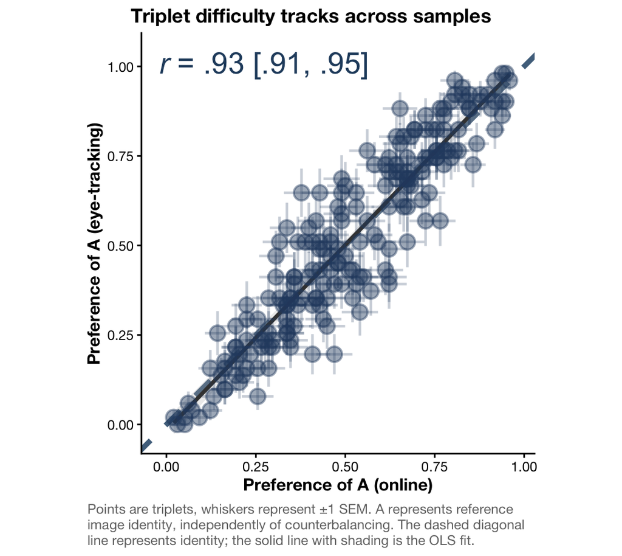

```r
cross_ct <- cor.test(rvw$m_online, rvw$m_eyetracking)
cross_number <- fmt_r(cross_ct)

p_cross <-
  rvw |>
  ggplot() +
  aes(
    x = m_online,
    xmin = m_online - sem_online,
    xmax = m_online + sem_online,
    y = m_eyetracking,
    ymin = m_eyetracking - sem_eyetracking,
    ymax = m_eyetracking + sem_eyetracking
  ) +
  geom_abline(
    slope = 1,
    intercept = 0,
    colour = COL_NULL,
    linetype = "dashed",
    linewidth = 0.8 * LWD
  ) +
  geom_smooth(
    method = "lm",
    formula = y ~ x,
    colour = "grey25",
    fill = "grey70",
    linewidth = 0.6 * LWD,
    alpha = 0.25
  ) +
  geom_pointrange(
    alpha = .25,
    size = 0.5 * ANN,
    linewidth = 0.4 * LWD,
    colour = navy
  ) +
  geom_pointrange(
    orientation = "y",
    alpha = .25,
    size = 0.5 * ANN,
    linewidth = 0.4 * LWD,
    colour = navy
  ) +
  ggtext::geom_richtext(
    data = tibble::tibble(x = -0.02, y = 1.04, lab = cross_number),
    aes(x = x, y = y, label = lab),
    inherit.aes = FALSE,
    hjust = 0,
    vjust = 1,
    size = 3.4 * ANN,
    colour = navy,
    fill = NA,
    label.colour = NA,
    label.padding = unit(rep(0, 4), "pt")
  ) +
  labs(
    x = "Preference of A (online)",
    y = "Preference of A (eye-tracking)"
  ) +
  panel_text(
    claim  = "Triplet difficulty tracks across samples",
    number = NULL,
    how    = paste(
      "Points are triplets, whiskers represent \u00b11 SEM.",
      "A represents reference image identity, independently of counterbalancing.",
      "The dashed diagonal line represents identity; the solid line with shading is the OLS fit."
    )
  ) +
  theme(
    axis.title.y = element_text(angle = 90)
  ) +
  coord_fixed()

p_cross
```

## 2.2 Binned cross-study agreement

```r
bins_wide <-
  difficulty_data |>
  distinct(experiment, tid, agreement_bin) |>
  mutate(
    agreement_bin = forcats::fct_relabel(agreement_bin, \(x) str_replace(x, "% ", "%\n"))
  ) |>
  pivot_wider(
    id_cols = tid,
    names_from = experiment,
    values_from = agreement_bin
  ) |>
  mutate(
    across(
      c(online, eyetracking),
      # NOTE: droplevels() also removes any genuinely empty agreement bin, which
      # would silently lose a row/column. Harmless here, worth knowing.
      \(x) forcats::fct_na_value_to_level(x, "(absent)") |> droplevels()
    )
  )
```

```r
bin_shift <-
  bins_wide |>
  filter(online != "(absent)", eyetracking != "(absent)") |>
  mutate(shift = abs(as.integer(eyetracking) - as.integer(online))) |>
  count(shift, name = "n") |>
  mutate(pct = n / sum(n))

# Percentages run WITHIN each online bin (i.e. down each column), so a column
# answers "of the triplets the online study called X, where did the eye-tracking
# study put them?".
bin_confusion <-
  bins_wide |>
  count(online, eyetracking, name = "n", .drop = FALSE) |>
  group_by(online) |>
  mutate(pct = n / sum(n)) |>
  ungroup() |>
  filter(n > 0)
```

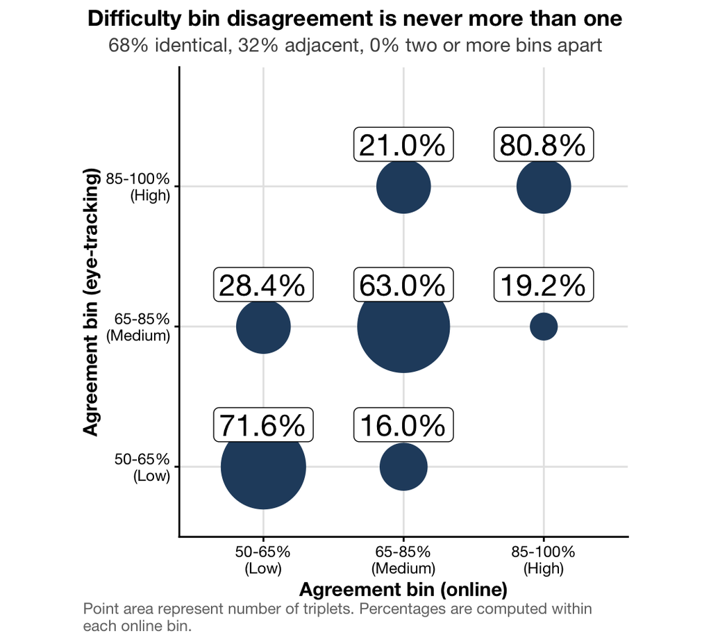

```r
bin_pct <- function(pred) 100 * sum(bin_shift$pct[pred])

bins_number <- sprintf(
  "%.0f%% identical, %.0f%% adjacent, %.0f%% two or more bins apart",
  bin_pct(bin_shift$shift == 0),
  bin_pct(bin_shift$shift == 1),
  bin_pct(bin_shift$shift >= 2)
)

p_bins <-
  bin_confusion |>
  ggplot() +
  aes(x = online, y = eyetracking) +
  geom_point(aes(size = n), colour = navy) +
  geom_label(
    aes(label = scales::percent(pct, accuracy = 0.1)),
    nudge_y = 0.30,
    size = 3 * ANN,
    label.padding = unit(0.15, "lines")
  ) +
  scale_size_area(max_size = 12 * ANN) +
  scale_y_discrete(expand = expansion(add = c(0.5, 0.85))) +
  scale_x_discrete(expand = expansion(add = 0.6)) +
  labs(
    x = "Agreement bin (online)",
    y = "Agreement bin (eye-tracking)"
  ) +
  panel_text(
    claim = "Difficulty bin disagreement is never more than one",
    number = bins_number,
    how = paste(
      "Point area represent number of triplets.",
      "Percentages are computed within each online bin."
    )
  ) +
  theme(
    axis.title.y = element_text(angle = 90),
    panel.grid.major = element_line(colour = "grey90"),
    legend.position = "none"
  ) +
  coord_fixed()

p_bins
```

## 2.3 Poster panel

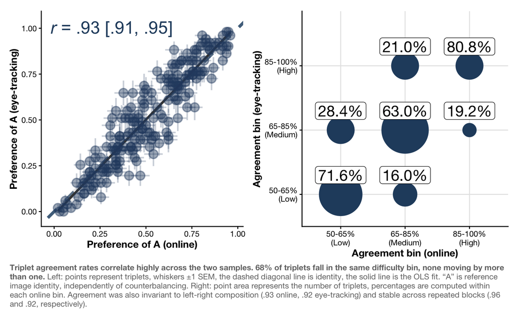

```r
# Reference image side / triplet repetition reliability texts
side_r <-
  rrw |>
  group_by(experiment) |>
  summarise(r = cor(m_FALSE, m_TRUE), .groups = "drop")

stab_r <- dss |>
  group_by(experiment) |>
  summarise(r = cor(m_1, m_6), .groups = "drop")

# ---- Poster panel caption ----
bin_same <- bin_pct(bin_shift$shift == 0)
bin_max  <- max(bin_shift$shift)

difficulty_finding <- sprintf(
  "**Triplet agreement rates correlate highly across the two samples. %.0f%% of triplets fall in the same difficulty bin%s.**",
  bin_same,
  if (bin_max <= 1) {
    ", none moving by more than one"
  } else {
    sprintf(", the largest disagreement being %d bins", bin_max)
  }
)

difficulty_how <- sprintf(
  paste(
    "Left: points represent triplets, whiskers ±1 SEM, the dashed diagonal line is identity, the solid line is the OLS fit.",
    '"A" is reference image identity, independently of counterbalancing.',
    "Right: point area represents the number of triplets, percentages are computed within each online bin.",
    "Agreement was also invariant to left-right composition (%s online, %s eye-tracking)",
    "and stable across repeated blocks (%s and %s, respectively)."
  ),
  no0(side_r$r[side_r$experiment == "online"]),
  no0(side_r$r[side_r$experiment == "eyetracking"]),
  no0(stab_r$r[stab_r$experiment == "online"]),
  no0(stab_r$r[stab_r$experiment == "eyetracking"])
)

# ---- Plotting proper ----
p_r2c1_difficulty <-
  (
    (p_cross | p_bins) &
      labs(title = NULL, subtitle = NULL, caption = NULL)
  ) +
  poster_caption(
    difficulty_finding,
    difficulty_how
  )

p_r2c1_difficulty
```

## 2.4 Summary

Triplet agreement rates correlate at *r* = .93 between the two samples and 68% of triplets fall in the same difficulty bin with none moving by more than one. Agreement is also invariant to which reference appears on the left (*r* = .92 in the eye-tracking sample) and stable across repeated blocks (*r* = .92).

> Difficulty is therefore considered to be a property of the triplet rather than of the sample or the display and the agreement bins are treated as a legitimate way to stratify triplets for ensuing analyses.

# 3 · Eye-tracking build

Data-building, not analysis. Fixation reports, the screen `layout`, participant metadata and the response data are joined into a single `{mathpsychr}` eye-tracking object, from which AOI-scoped measures are derived.

The step that matters conceptually is the **chosen/unchosen recoding**, whereby raw `left`/`right`/`query` AOIs are mapped to the reference the participant *ended up choosing* versus the one they rejected. Query image coding remains untouched.

## 3.1 Build basic data

```r
# NOTE: Unlike comparisons between online and eye-tracking data difficulty
# structure, eye-tracking data fixation analyses need more than just response
# data preprocessing. Here, we build an eye-tracking data from response,
# fixation and meta data altogether.

# ---- Responses ----
# NOTE: although we could build from scratch via `append_majority_coding()`, to
# keep the data explicitly comparable, we instead continue from the difficulty
# structure analysis response data instead.
dp_responses <-
  difficulty_data |>
  filter(experiment == "eyetracking") |>
  mutate(response_time = response_time / 1e3) |> # ms -> s
  rename(subject_id = id) |>
  select(-experiment)

# ---- Fixations ----
# NOTE: the same trial filter as above is applied via `dplyr::semi_join()`
# instead of calling the internal `tripletviewing:::.identify_catch_trials()`.
dp_fixations <-
  decisionprocessdata$fix |>
  rename(subject_id = id) |>
  semi_join(dp_responses, by = join_by(subject_id, block, trial)) |>
  mutate(across(c("stime", "etime", "dur"), \(x) x / 1e3))

# ---- Metadata ----
dp_meta <-
  decisionprocessdata$meta |>
  rename(subject_id = id) |>
  semi_join(dp_responses, by = join_by(subject_id))

# ---- Eye-tracking data build via {mathpsychr} ----
eyelink_data <- mathpsychr::build_eyelink_eyetracking(
  fixations = dp_fixations,
  layout    = layout,
  metadata  = dp_meta,
  responses = dp_responses
)
```

## 3.2 Process gaze measures

```r
# NOTE: the process is described in more detail in the {mathpsychr}'s working
# version vignette
poster_stats <- c(
  # AOI scope
  "fixation_count",
  "dwell_time_total",
  # Stimulus scope
  "switches_total",
  "watch_time",
  "first_reference_fixation_start",
  # Categorical
  "first_fixated_reference",
  "last_fixated_reference"
)

em_data <- mathpsychr::process(
  eyelink_data,
  type = "measures",
  trial_vars = c("block", "trial"),
  grp_vars = "agreement_bin",
  stats = poster_stats,
  window = Inf,
  query_aoi = "query",
  reference_aois = c("left", "right"),
  chosen_aoi_col = "chosen_aoi",
  response_opts = c("left", "right")
)
```

## 3.3 Prepare wide data for prediction models

```r
trial_data_combined <-
  dp_responses |>
  left_join(
    mathpsychr::flatten(em_data)$derivatives,
    by = join_by(subject_id, block, trial, agreement_bin)
  ) |>
  mutate(
    dwell_chosen    = dwell_time_total_chosen,
    dwell_unchosen  = dwell_time_total_unchosen,
    dwell_query     = dwell_time_total_query,
    dwell_diff      = dwell_chosen - dwell_unchosen,
    fix_count_total = fixation_count_chosen + fixation_count_unchosen + fixation_count_query
  )
```

## 3.4 Summary

`trial_data_combined` now holds one row per trial with dwell time on the chosen, unchosen and query AOIs, total fixation count and the agreement bin. Sections 4 and 6 both build on it, whereas Section 5 goes back to the fixation data directly.

# 4 · Gaze measures (row 2, column 2; RQ2)

> **RQ2: Does difficulty change how much, and where, people look?**

This section covers two gaze measures, which are deliberately different in kind.

**First fixated reference** is categorical. It says which one of the two references was fixated first, and whether that was the one eventually chosen. At chance level this quantity is 50%. It is a measure of how early gaze commits and it is analysed with a binomial GLMM with crossed participant- and triplet-specific intercepts.

**Dwell time** is continuous. It measures total time inside each reference AOI during a selected time window. Here, it is measured over two windows, being the **full trial** and the **first 1.25 s**. The short window is set so that most trials contain a genuine comparison (77% have at least two reference fixations) while still ending before the gaze cascade (see Section 5) takes hold. The two windows answer different questions: the full trial measures *how much* looking a triplet attracts, the opening window measures *how that looking is divided* before committing to a decision.

## 4.1 First/last fixated option hierarchical binomial regression

### 4.1.1 Data

```r
# Outcome variables
fix_markers <- c(
  "first_fixated_reference",
  "last_fixated_reference"
)

# Data
fix_trials <-
  trial_data_combined |>
  select(subject_id, tid, agreement_bin, all_of(fix_markers)) |>
  pivot_longer(
    cols = all_of(fix_markers),
    names_to = "marker",
    values_to = "fixated_reference"
  ) |>
  filter(!is.na(fixated_reference)) |>
  mutate(
    marker = factor(
      marker,
      levels = fix_markers,
      labels = c("First fixated reference", "Last fixated reference")
    ),
    is_chosen = as.integer(fixated_reference == "chosen")
  )
```

### 4.1.2 Models

```r
fix_ctrl <- glmerControl(optimizer = "bobyqa")

fix_models <-
  fix_trials |>
  group_nest(marker) |>
  mutate(
    fit = map(data, \(d) glmer(
      is_chosen ~ agreement_bin + (1 | subject_id) + (1 | tid),
      data = d,
      family = binomial,
      control = fix_ctrl
    ))
  )

# Singular fit check (commented out as successfully passed).
#walk2(fix_models$marker, fix_models$fit, \(nm, m) {
#  if (lme4::isSingular(m)) {
#    warning("Singular fit for ", nm, "; inspect VarCorr() before reporting.", call. = FALSE)
#  }
#})
#map(fix_models$fit, \(m) summary(m)$varcor)

# Omnibus tests of the agreement bin factor.
fix_omnibus <-
  fix_models |>
  mutate(
    fit_null = map(data, \(d) glmer(
      is_chosen ~ 1 + (1 | subject_id) + (1 | tid),
      data = d,
      family = binomial,
      control = fix_ctrl
    )),
    omnibus = map2(fit_null, fit, \(m0, m1) {
      a <- anova(m0, m1)
      tibble::tibble(
        chisq = a[["Chisq"]][2],
        df = a[["Df"]][2],
        p = a[["Pr(>Chisq)"]][2]
      )
    })
  ) |>
  select(marker, omnibus) |>
  unnest(omnibus) |>
  mutate(
    label = sprintf(
      "\u03c7\u00b2(%d) = %.1f, %s",
      df, chisq,
      if_else(p < .001, "p < .001", sprintf("p = %.3f", p))
    )
  )
#fix_omnibus

# Model-based proportions and all pairwise bin contrasts.
fix_predictions <-
  fix_models |>
  mutate(pred = map(fit, \(m) {
    marginaleffects::avg_predictions(m, by = "agreement_bin", re.form = NA) |>
      tibble::as_tibble()
  })) |>
  select(marker, pred) |>
  unnest(pred)

fix_contrasts <-
  fix_models |>
  mutate(cmp = map(fit, \(m) {
    marginaleffects::avg_comparisons(
      m, variables = list(agreement_bin = "pairwise"), re.form = NA
    ) |>
      tibble::as_tibble()
  })) |>
  select(marker, cmp) |>
  unnest(cmp)

#fix_predictions
#fix_contrasts
```

### 4.1.3 Plot

```r
# Helper function to print either first, last or first/last fixation boxplots.
# NOTE: albeit for the poster only the first fixation plot is used, the last
# fixation analysis is mentioned in the caption and can be inspected here.
fix_subject_props <-
  fix_trials |>
  group_by(marker, agreement_bin, subject_id) |>
  summarise(prop = mean(is_chosen), n_trials = n(), .groups = "drop")

plot_fixation_marker <- function(
    markers = levels(fix_subject_props$marker),
    ann = 1
) {
  props <- filter(fix_subject_props, marker %in% markers)
  preds <- filter(fix_predictions,   marker %in% markers)

  p <-
    props |>
    ggplot() +
    aes(
      x = agreement_bin,
      y = prop,
      fill = agreement_bin,
      colour = agreement_bin
    ) +
    geom_hline(
      yintercept = 0.5,
      linetype = "dotted",
      colour = COL_NULL,
      linewidth = 0.5 * ann
    ) +
    geom_violin(
      colour = NA,
      alpha = 0.35,
      width = 0.9
    ) +
    geom_point(
      position = position_jitter(width = 0.10, height = 0),
      alpha = 0.25,
      size = 1.75 * ann
    ) +
    geom_pointrange(
      data = preds,
      aes(x = agreement_bin, y = estimate, ymin = conf.low, ymax = conf.high),
      inherit.aes = FALSE,
      colour = "black",
      linewidth = 0.9 * ann,
      size = 0.65 * ann
    ) +
    scale_x_discrete(labels = \(x) short_bin(x)) +
    scale_y_continuous(labels = scales::percent) +
    scale_fill_manual(values = bin_pal, guide = "none") +
    scale_colour_manual(values = bin_pal, guide = "none") +
    labs(x = "Agreement bin", y = "P(fixated reference = chosen)") +
    theme(axis.title.y = element_text(angle = 90))

  p
}
```

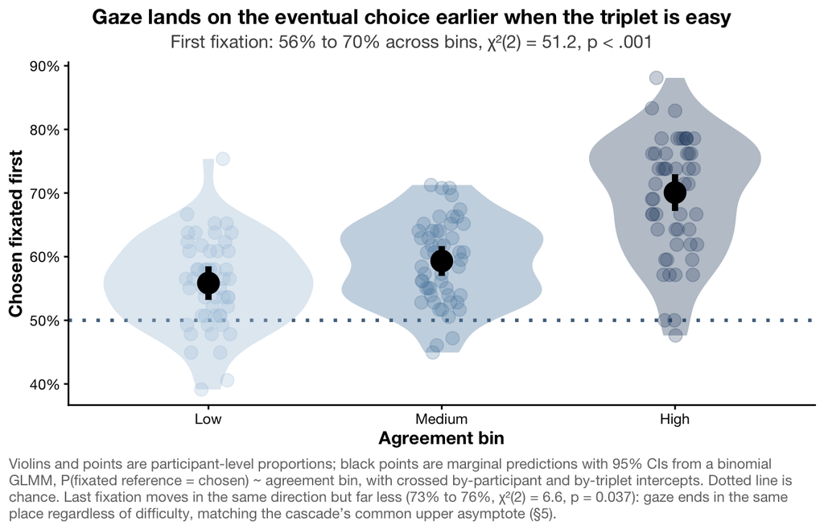

```r
# ---- First fixation plot ----
last_range <- filter(fix_predictions, marker == "Last fixated reference")$estimate
first_lrt  <- filter(fix_omnibus, marker == "First fixated reference")
last_lrt   <- filter(fix_omnibus, marker == "Last fixated reference")

first_fix_number <- sprintf(
  "First fixation: %.0f%% to %.0f%% across bins, %s",
  100 * min(filter(fix_predictions, marker == "First fixated reference")$estimate),
  100 * max(filter(fix_predictions, marker == "First fixated reference")$estimate),
  first_lrt$label
)

first_fix_how <- sprintf(
  paste(
    "Violins and points are participant-level proportions; black points are marginal",
    "predictions with 95%% CIs from a binomial GLMM, P(fixated reference = chosen) ~",
    "agreement bin, with crossed by-participant and by-triplet intercepts.",
    "Dotted line is chance.",
    "Last fixation moves in the same direction but far less (%.0f%% to %.0f%%, %s):",
    "gaze ends in the same place regardless of difficulty, matching the cascade's",
    "common upper asymptote (§5)."
  ),
  100 * min(last_range),
  100 * max(last_range),
  last_lrt$label
)

p_fix_first <-
  plot_fixation_marker("First fixated reference", ann = ANN) +
  labs(y = "Chosen fixated first") +
  panel_text(
    claim  = "Gaze lands on the eventual choice earlier when the triplet is easy",
    number = first_fix_number,
    how    = first_fix_how
  )

p_fix_first
```

## 4.2 Opening moments dwell times

### 4.2.1 Window size selection

The short window has to be long enough that most trials contain a genuine chosen-versus-unchosen comparison, all the while being short enough to end before the gaze cascade (see Section 5) takes hold. Both criteria depend only on the fixation and response-time distributions, never on the chosen/unchosen contrast, so the window is not selected on the outcome it is later used to measure.

```r
# How far before the response the cascade is assumed to begin.
cascade_onset_lead <- 0.7 # SPOILERS

window_diag <- map_dfr(seq(0.75, 2.0, by = 0.25), \(w) {
  em_w <- mathpsychr::process(
    eyelink_data,
    type = "measures",
    trial_vars = c("block", "trial"),
    grp_vars = "agreement_bin",
    stats = "fixation_count",
    window = w,
    query_aoi = "query",
    reference_aois = c("left", "right"),
    chosen_aoi_col = "chosen_aoi",
    response_opts = c("left", "right")
  )

  mathpsychr::flatten(em_w)$derivatives |>
    mutate(
      n_ref =
        .data[[paste0("fixation_count_", w, "_chosen")]] +
        .data[[paste0("fixation_count_", w, "_unchosen")]]
    ) |>
    left_join(
      select(dp_responses, subject_id, block, trial, response_time),
      by = join_by(subject_id, block, trial)
    ) |>
    summarise(
      window = w,
      pct_zero = 100 * mean(n_ref == 0, na.rm = TRUE),
      pct_two_plus = 100 * mean(n_ref >= 2, na.rm = TRUE),
      pct_complete = 100 * mean(response_time <= w, na.rm = TRUE),
      pct_cascade_clean = 100 * mean(response_time >= w + cascade_onset_lead, na.rm = TRUE),
      # Joint criterion: a trial is usable if it contains a possibility for a
      # real comparison AND ends late enough that the window predates the
      # cascade.
      pct_usable = 100 * mean(n_ref >= 2 & response_time >= w + cascade_onset_lead, na.rm = TRUE)
    )
})

window_diag
```

```
#> # A tibble: 6 × 6
#>   window pct_zero pct_two_plus pct_complete pct_cascade_clean pct_usable
#>    <dbl>    <dbl>        <dbl>        <dbl>             <dbl>      <dbl>
#> 1   0.75   39.9           12.0        0.402              89.4       10.7
#> 2   1       9.51          43.8        1.97               83.0       34.5
#> 3   1.25    3.15          76.9        5.69               76.4       56.9
#> 4   1.5     1.57          90.2       12.0                70.0       61.8
#> 5   1.75    0.784         95.1       18.4                63.9       60.0
#> 6   2       0.529         97.4       25.0                58.1       56.2
```

### 4.2.2 Data extraction

```r
# IMPORTANT: Criterion is to maximise the share of trials that both contain a
# potential for real chosen-vs-unchosen comparison (>= 2 reference fixations)
# AND end late enough that the window predates the cascade (RT >= window + 0.7
# s). Both depend only on the fixation and response time distributions, never
# on the chosen/unchosen contrast, so the choice is not made on the outcome.
#
# Tie-break: where pct_usable is flat, prefer the shorter window, because both
# contaminants grow with window length.
short_window <- 1.25

short_window_name <- sprintf(
  "First %g second%s",
  short_window,
  if (short_window == 1L) "" else "s"
)

short_window_chosen_dwell_col   <- paste0("dwell_time_total_", short_window, "_chosen")
short_window_unchosen_dwell_col <- paste0("dwell_time_total_", short_window, "_unchosen")

stats_short <- c(
  "first_fixated_reference",
  "dwell_time_total",
  "fixation_count"
)

em_data_short <- process(
  eyelink_data,
  type = "measures",
  trial_vars = c("block", "trial"),
  grp_vars = "agreement_bin",
  stats = stats_short,
  window = short_window,
  query_aoi = "query",
  reference_aois = c("left", "right"),
  chosen_aoi_col = "chosen_aoi",
  response_opts = c("left", "right")
)
```

### 4.2.3 Data processing

```r
short_wide <- mathpsychr::flatten(em_data_short)$derivatives

dwell_by_window <-
  bind_rows(
    trial_data_combined |>
      mutate(
        subject_id    = subject_id,
        agreement_bin = agreement_bin,
        chosen        = dwell_chosen,
        unchosen      = dwell_unchosen,
        window        = "Full trial",
        .keep         = "none"
      ),
    tibble::tibble(
      subject_id    = short_wide$subject_id,
      agreement_bin = short_wide$agreement_bin,
      chosen        = short_wide[[short_window_chosen_dwell_col]],
      unchosen      = short_wide[[short_window_unchosen_dwell_col]],
      window        = short_window_name
    )
  ) |>
  pivot_longer(
    c(chosen, unchosen),
    names_to = "reference",
    values_to = "dwell"
  ) |>
  # Participant-level means
  group_by(
    window,
    agreement_bin,
    reference,
    subject_id
  ) |>
  summarise(
    dwell = mean(dwell, na.rm = TRUE),
    .groups = "drop"
  ) |>
  mutate(
    window = factor(
      window,
      levels = c("Full trial", short_window_name)
    ),
    reference = factor(
      reference,
      levels = c("chosen", "unchosen"),
      labels = c("Chosen", "Unchosen")
    )
  )
```

### 4.2.4 Plot

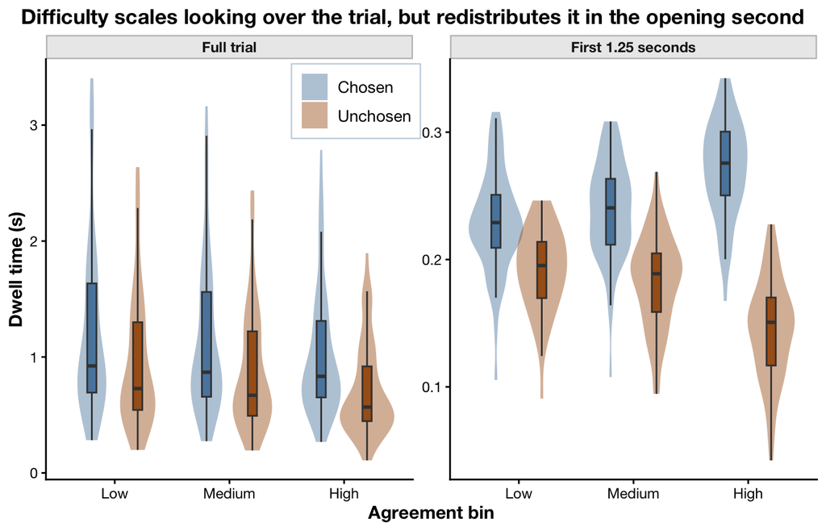

```r
# Windows naming
w_full <- "Full trial"
w_short <- sprintf(
  "First %g second%s",
  short_window,
  if (short_window == 1L) "" else "s"
)

# Direct labels replace the legend to save space. Offsets derived from data.
dodge_w <- 0.8

ref_key <-
  dwell_by_window |>
  filter(window == w_full, agreement_bin == levels(agreement_bin)[1]) |>
  group_by(reference) |>
  summarise(top = max(dwell, na.rm = TRUE), .groups = "drop") |>
  mutate(
    x = 1 + if_else(reference == "Chosen", -dodge_w / 4, dodge_w / 4),
    y = max(top) * 1.03
  )

# Extract ANOVA results
ts_cols <- c(
  measure = "stat",
  effect  = "Effect",
  df1     = "DFn",
  df2     = "DFd",
  Fval    = "F",
  p       = "p",
  pes     = "pes"
)

# Extract summaries
short_complete <-
  dp_responses |>
  group_by(agreement_bin) |>
  summarise(
    n_trials = n(),
    pct_complete = 100 * mean(response_time <= short_window, na.rm = TRUE),
    .groups = "drop"
  )

pct_complete_all <- 100 * mean(dp_responses$response_time <= short_window, na.rm = TRUE)

trend_of <- function(w, r) {
  dwell_trend$pct_change[dwell_trend$window == w & dwell_trend$reference == r]
}

dwell_trend <-
  dwell_by_window |>
  group_by(window, agreement_bin, reference) |>
  summarise(m = mean(dwell, na.rm = TRUE), .groups = "drop") |>
  arrange(window, reference, agreement_bin) |>
  group_by(window, reference) |>
  summarise(
    low = first(m),
    high = last(m),
    pct_change = 100 * (high - low) / low,
    .groups = "drop"
  )

p_dwell_windows <-
  dwell_by_window |>
  ggplot() +
  aes(
    x = agreement_bin,
    y = dwell,
    fill = reference
  ) +
  geom_violin(
    colour = NA,
    alpha = 0.45,
    position = position_dodge(dodge_w),
    width = 0.95
  ) +
  geom_boxplot(
    width = 0.16,
    outlier.shape = NA,
    position = position_dodge(dodge_w),
    colour = "grey25",
    show.legend = FALSE
  ) +
  facet_wrap(
    ~window,
    scales = "free_y"
  ) +
  scale_x_discrete(labels = \(x) short_bin(x)) +
  scale_fill_manual(values = ref_pal) +
  labs(
    x = "Agreement bin",
    y = "Dwell time (s)",
    fill = NULL
  ) +
  panel_text(
    claim  = "Difficulty scales looking over the trial, but redistributes it in the opening second",
    number = NULL,
    how    = NULL
  ) +
  theme(
    legend.position = "inside",
    legend.position.inside = c(0.402, 0.90),
    axis.title.y = ggtext::element_markdown(angle = 90)
  )

p_dwell_windows
```

## 4.3 Poster panel

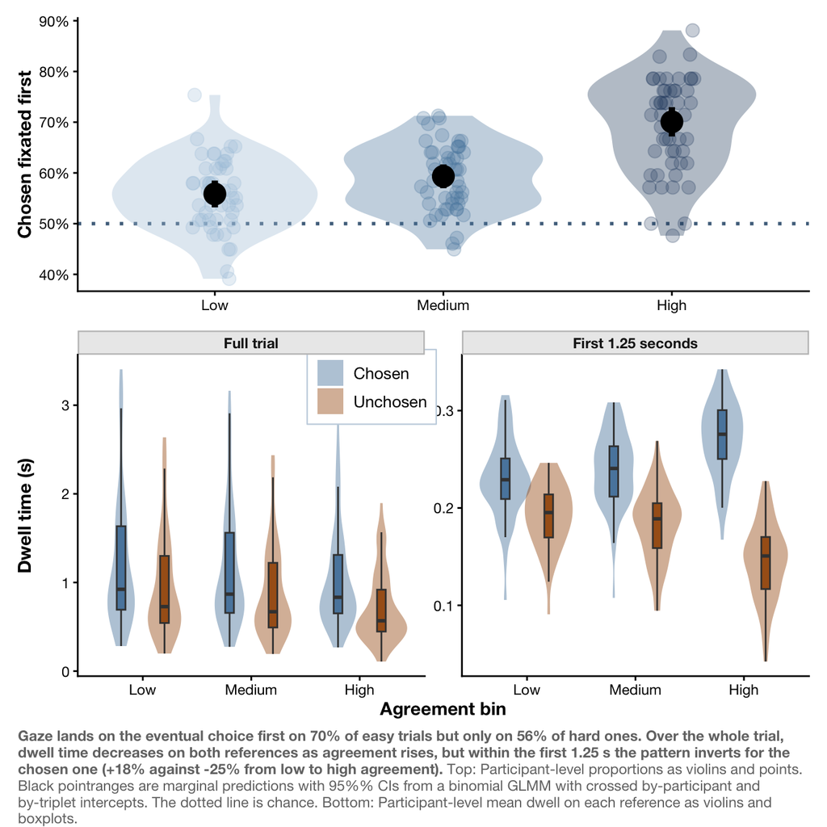

```r
first_est <- filter(fix_predictions, marker == "First fixated reference")$estimate

# ---- Poster caption ----
measures_finding <- sprintf(
  paste(
    "**Gaze lands on the eventual choice first on %.0f%% of easy trials but only on %.0f%% of hard ones.",
    "Over the whole trial, dwell time decreases on both references as agreement rises, but within the first %g s the pattern inverts for the chosen one (%+.0f%% against %+.0f%% from low to high agreement).**"
  ),
  100 * max(first_est),
  100 * min(first_est),
  short_window,
  trend_of(w_short, "Chosen"),
  trend_of(w_short, "Unchosen")
)

measures_how <- paste(
    "Top: Participant-level proportions as violins and points. Black pointranges are marginal predictions with 95%% CIs from a binomial GLMM with crossed by-participant and by-triplet intercepts. The dotted line is chance.",
    "Bottom: Participant-level mean dwell on each reference as violins and boxplots."
)

# ---- Plotting proper ----
p_r2c2_measures <-
  (
    (p_fix_first / p_dwell_windows) &
      labs(title = NULL, subtitle = NULL, caption = NULL)
  ) +
  plot_layout(
    heights = c(0.85, 1),
    axis_titles = "collect_x"
  ) +
  poster_caption(
    measures_finding,
    measures_how
  )

p_r2c2_measures
```

## 4.4 Summary

Gaze lands on the eventually chosen reference first on 70% of easy trials against 56% of hard ones. While both of these values sit well above chance, the first reference image fixation proportion is clearly graded by difficulty.

Dwell time separates the two windows. Over the full trial, difficulty scales looking on *both* references (chosen -17%, unchosen -26% from Low to High agreement). Within the opening 1.25 s the pattern *inverts* for the chosen reference (+18% against -25%). Total viewing time is capped by construction, so what difficulty changes in the opening viewing moments is the attention *split* between the two options.

**Difficulty therefore seems to act on effort across the trial and on allocation in the moments before commitment.**

# 5 · Gaze cascade (row 3, column 1; RQ3)

> **RQ3: Does difficulty change *when* gaze commits to the eventual choice?**

The **gaze cascade** is the observation that in the final moments before a two-alternative choice, gaze drifts increasingly towards the option about to be chosen. It appears as a chosen/unchosen dwell ratio that rises sharply as the response approaches.

Here it is summarised by a four-parameter sigmoid fitted to the grand average over the 2 s preceding the response:

| Parameter | Meaning | What a difference would mean |
| --- | --- | --- |
| **L** | baseline | commitment begins from a different starting bias |
| **U** | upper asymptote | gaze proportion ends up at different levels |
| **k** | steepness | commitment happens faster or slower |
| **t<sub>0</sub>** | inflection point | commitment happens earlier or later |

Sigmoid curves are fitted separately per agreement bin and compared by resampling recordings.

## 5.1 Window size selection

The cascade is estimated as a grand average over the seconds preceding the response, so a trial contributes to the average at time −*t* only if it lasted at least *t* seconds. The window therefore trades reach against coverage: the further back it extends, the fewer trials are still running, and the more its early portion is carried by slow trials alone.

Two points deserve special attention. Coverage has to hold **within every agreement bin**, not only on average (hard triplets take longer). And the criterion must not touch the chosen/unchosen contrast. Like §4.2.1, the window for gaze cascade is computed from response times alone, so the window is not selected on the outcome it is later used to measure.

```r
# Share of trials still running w seconds before the response, per agreement
# bin. A trial contributes to the grand average at time -w only if it lasted
# at least w, so this is exactly the coverage at the window's far edge.
compute_coverage <- function(w) {
  dp_responses |>
    group_by(agreement_bin) |>
    summarise(
      n_trials = n(),
      pct_reaching_window = 100 * mean(response_time >= w, na.rm = TRUE),
      .groups = "drop"
    )
}
```

```r
# The window is chosen on the WORST bin, never on the mean across bins
cascade_coverage_table <-
  map_dfr(seq(1, 3.5, by = 0.5), \(w) mutate(compute_coverage(w), window = w)) |>
  mutate(agreement_bin = short_bin(agreement_bin)) |>
  group_by(window) |>
  mutate(worst_bin = min(pct_reaching_window)) |>
  ungroup() |>
  select(window, agreement_bin, pct_reaching_window, worst_bin) |>
  pivot_wider(names_from = agreement_bin, values_from = pct_reaching_window) |>
  relocate(worst_bin, .after = last_col())

cascade_coverage_table
```

```
#> # A tibble: 6 × 5
#>   window   Low Medium  High worst_bin
#>    <dbl> <dbl>  <dbl> <dbl>     <dbl>
#> 1    1    98.4   98.2  97.1      97.1
#> 2    1.5  89.7   88.5  84.5      84.5
#> 3    2    77.2   76.0  69.6      69.6
#> 4    2.5  65.9   63.7  55.6      55.6
#> 5    3    54.4   52.5  44.1      44.1
#> 6    3.5  45.5   43.8  35.8      35.8
```

```r
cascade_window <- 2
cascade_n_bins <- 60L
cascade_bin_w  <- cascade_window / cascade_n_bins

compute_coverage(cascade_window)
```

```
#> # A tibble: 3 × 3
#>   agreement_bin   n_trials pct_reaching_window
#>   <fct>              <int>               <dbl>
#> 1 50-65% (Low)        3519                77.2
#> 2 65-85% (Medium)     4539                76.0
#> 3 85-100% (High)      2142                69.6
```

## 5.2 Data processing

```r
gc_data <- process(
  eyelink_data,
  type = "cascade",
  trial_vars = c("block", "trial"),
  grp_vars = "agreement_bin",
  window = cascade_window,
  n_bins = cascade_n_bins,
  response_time_col = "response_time",
  chosen_aoi_col = "chosen_aoi"
)
```

## 5.3 Statistical analysis (bootstrapping)

```r
gc_bootstrap <- compute(
  gc_data,
  fit_type = c("sigmoid", "piecewise"),
  n_boot = 2000L,
  alpha = 0.05,
  ci_type = "bca",
  seed = 87542
)
```

### 5.3.1 (Non-)convergence

```r
convergence <-
  purrr::imap_dfr(gc_bootstrap$fits, \(fit, type) tibble::tibble(
    fit_type = type,
    n_boot = gc_bootstrap$boot$R,
    n_failed = fit$n_failed,
    pct_failed = 100 * fit$n_failed / gc_bootstrap$boot$R
  ))

conv_failed_sigmoid <-
  convergence |>
  filter(fit_type == "sigmoid") |>
  pull(pct_failed)

conv_failed_piece <-
  convergence |>
  filter(fit_type == "piecewise") |>
  pull(pct_failed)
```

## 5.4 Poster panel

```r
# Observed sigmoid fit
sigmoid_obs <- gc_bootstrap$fits$sigmoid$observed

# Sigmoid fits for plotting
curve_fits <-
  sigmoid_obs |>
  mutate(t = list(seq(-cascade_window, 0, length.out = 400))) |>
  tidyr::unnest(t) |>
  mutate(fitted = mathpsychr:::.sigmoid(t, param_L, param_U, param_k, param_t0))

# Legend labels (carry R^2)
fit_labs <- setNames(
  sprintf("%s  (R\u00b2 = %.2f)", sigmoid_obs$group_name, sigmoid_obs$r2),
  sigmoid_obs$group_name
)

# Coverage curve to indicate data availability
cov_lo <- 0.432 # bottom of the strip, below the 0.5 chance line
cov_hi <- 0.492 # top of the strip

coverage_curve <-
  tibble::tibble(t = seq(-cascade_window, 0, length.out = 200)) |>
  mutate(
    cov = map_dbl(t, \(x) mean(dp_responses$response_time >= -x, na.rm = TRUE)),
    y   = cov_lo + (cov_hi - cov_lo) * cov
  )

cov_edge <- 100 * min(coverage_curve$cov)
cov_pad   <- 0.008
y_cov_lab <- min(coverage_curve$y) - cov_pad
y_floor   <- y_cov_lab - 0.018

# Baseline (L) per agreement bin and one bracket per contrast that excludes
# zero.
L_sig <-
  gc_bootstrap$diff_summary |>
  filter(fit_type == "sigmoid", parameter == "L", ci_low * ci_high > 0)

L_rng <- range(abs(L_sig$estimate))
L_by_group <- setNames(sigmoid_obs$param_L, sigmoid_obs$group_name)

L_brackets <-
  L_sig |>
  mutate(
    y     = pmin(as.numeric(L_by_group[group_a]), as.numeric(L_by_group[group_b])),
    yend  = pmax(as.numeric(L_by_group[group_a]), as.numeric(L_by_group[group_b])),
    label = sprintf("+%.3f", abs(estimate)),
    est   = abs(estimate),
    .keep = "none"
  ) |>
  arrange(desc(yend - y)) |>
  mutate(x = -cascade_window * (0.95 - 0.13 * (row_number() - 1)))
```

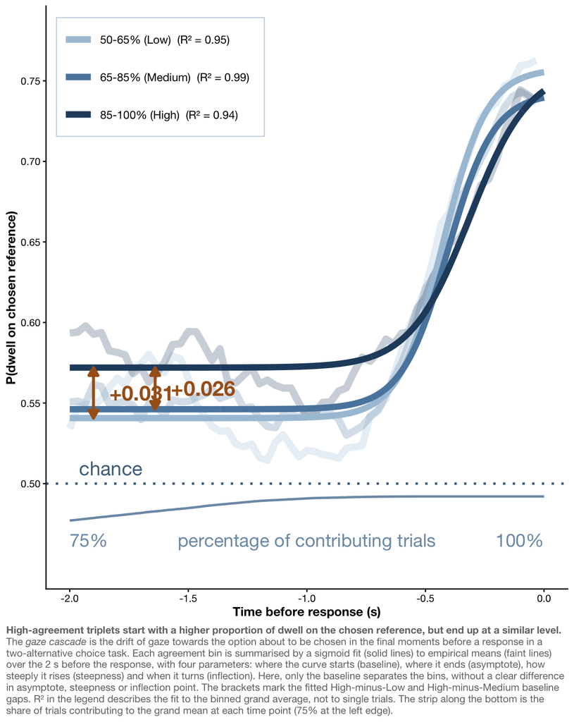

```r
# ---- Poster caption ----
cascade_finding <-
  "**High-agreement triplets start with a higher proportion of dwell on the chosen reference, but end up at a similar level.**"

cascade_how <- sprintf(
  paste(
    "The *gaze cascade* is the drift of gaze towards the option about to be chosen in the final moments before a response in a two-alternative choice task.",
    "Each agreement bin is summarised by a sigmoid fit (solid lines) to empirical means (faint lines) over the %g s before the response, with four parameters: where the curve starts (baseline), where it ends (asymptote), how steeply it rises (steepness) and when it turns (inflection).",
    "Here, only the baseline separates the bins, without a clear difference in asymptote, steepness or inflection point.",
    "The brackets mark the fitted High-minus-Low and High-minus-Medium baseline gaps.",
    "R\u00b2 in the legend describes the fit to the binned grand average, not to single trials.",
    "The strip along the bottom is the share of trials contributing to the grand mean at each time point (%.0f%% at the left edge)."
  ),
  cascade_window,
  cov_edge
)

# --- Empirical group means, drawn faintly behind the fits ----
grp_col  <- attr(gc_data$derivatives, "grp_vars")
time_col <- "bin"
bin_w <- cascade_window / cascade_n_bins

emp <-
  gc_data |>
  as.data.frame() |>
  group_by(
    across(all_of(c(grp_col, time_col)))
  ) |>
  summarise(
    m = mean(average_prop_chosen, na.rm = TRUE),
    .groups = "drop"
  ) |>
  rename(
    bin = all_of(time_col),
    group_name = all_of(grp_col)
  ) |>
  mutate(
    group_name = as.character(group_name),
    t = -cascade_window + (bin - min(bin)) * bin_w
  )

emp_layer <- geom_line(
  data = emp,
  aes(x = t, y = m, colour = group_name),
  alpha = 0.25,
  linewidth = 1.5 * LWD
)


# ---- Plotting proper ----
p_r3c1_cascade <-
  curve_fits |>
  ggplot() +
  aes(x = t, y = fitted, colour = group_name) +
  emp_layer +
  geom_hline(
    yintercept = 0.5,
    linetype = "dotted",
    colour = COL_NULL,
    linewidth = 0.5 * LWD
  ) +
  annotate(
    "text",
    x = -cascade_window,
    y = 0.5,
    label = "chance",
    hjust = -0.15,
    vjust = -0.6,
    size = 3 * ANN,
    colour = slate
  ) +
  geom_line(linewidth = 1.3 * LWD) +
  ## ---- Baseline brackets, one per significant contrast ----
   geom_segment(
    data = L_brackets,
    aes(x = x, xend = x, y = y, yend = yend),
    inherit.aes = FALSE,
    colour = COL_ACCENT,
    linewidth = 0.6 * LWD,
    arrow = grid::arrow(
      ends = "both",
      length = unit(4 * ANN, "pt"),
      type = "closed"
    )
  ) +
  geom_text(
    data = L_brackets,
    aes(x = x, y = (y + yend) / 2, label = label),
    inherit.aes = FALSE,
    hjust = -0.25,
    size = 3.2 * ANN,
    fontface = "bold",
    colour = COL_ACCENT
  ) +
  ## ---- Coverage strip ----
  geom_line(
    data = coverage_curve,
    aes(x = t, y = y),
    inherit.aes = FALSE,
    colour = dim_,
    linewidth = 0.5 * LWD
  ) +
  annotate(
    "text",
    x = -cascade_window,
    y = y_cov_lab,
    label = sprintf("%.0f%%", cov_edge),
    hjust = 0,
    vjust = 1,
    size = 2.8 * ANN,
    colour = dim_
  ) +
  annotate(
    "text",
    x = 0,
    y = y_cov_lab,
    label = "100%",
    hjust = 1,
    vjust = 1,
    size = 2.8 * ANN,
    colour = dim_
  ) +
  annotate(
    "text",
    x = -cascade_window / 2,
    y = y_cov_lab,
    label = "percentage of contributing trials",
    vjust = 1,
    size = 2.8 * ANN,
    colour = dim_
  ) +
  coord_cartesian(
    ylim = c(y_floor, 0.78),
    xlim = c(-cascade_window, 0)
  ) +
  scale_y_continuous(
    breaks = seq(0.50, 0.75, 0.05)
  ) +
  labs(
    x = "Time before response (s)",
    y = "P(dwell on chosen reference)",
    colour = NULL
  ) +
  scale_colour_manual(
    values = bin_pal,
    labels = fit_labs
  ) +
  poster_text(
    cascade_finding,
    cascade_how
  ) +
  theme(
    legend.position = "inside",
    legend.position.inside = c(0.02, 0.98),
    legend.justification = c(0, 1),
    legend.key.height = unit(2.5 * FIG_BASE, "pt"),
    legend.key.width = unit(2.5 * FIG_BASE, "pt"),
    legend.key.spacing.y = unit(0.5 * FIG_BASE, "pt"),
    legend.margin = margin(
      t = 0.5 * FIG_BASE,
      r = 1.2 * FIG_BASE,
      b = 0.5 * FIG_BASE,
      l = 0.5 * FIG_BASE
    ),
  )

p_r3c1_cascade
```

## 5.5 Summary

Only the **baseline** of the gaze cascade sigmoid moves detectably across agreement bins. High-agreement triplets start 0.031 higher than low-agreement ones, while the asymptote, the steepness and the inflection point all have contrast intervals overlapping zero. Across difficulty, the cascade has the same shape, the same timing and the same destination.

**Two caveats belong with the number.** The fits are descriptive, they do not represent proper statistical modelling of an assumed data-generating process. Furthermore, bootstrapping convergence is imperfect, as 2% of sigmoid and 21% of piecewise bootstrap replicates failed to converge. Reported statistics summarise the replicates that did converge and only the sigmoid fit is discussed for brevity’s sake (piecewise linear modelling endeavours, although with poorer parameter convergence, lead to the same conclusion).

# 6 · Response prediction (row 3, column 2; RQ4)

> **RQ4: Which gaze measures predict a majority-consistent choice?**

The outcome is whether the participant’s response on a trial matched the majority response for that triplet.[^1]

This section uses four trial-level predictors (independent variables, IVs): dwell on the chosen reference, on the unchosen reference, on the query, and total fixation count. All are log-transformed and then z-scaled, so effects are comparable and read “per 1 SD.”

The IVs are entered in three model families, because the question is not simply whether each predicts in isolation, but also which survives adjustment for the others:

- **Alone**: one predictor per model
- **Paired**: each dwell term with fixation count, the obvious confound, since a trial scanned more will accumulate dwell everywhere
- **All four**: the adjudicating model

Effects are reported as **average marginal effects**, i.e., the change in the probability of a majority-consistent response per 1 SD of the predictor, at the population-level with random effects marginalised out.

## 6.1 Data

```r
# The line below restores the millisecond scale for the transform only, so these
# estimates stay directly comparable to the existing vignette and to the poster's
# numbers.
to_ms <- 1e3

dcm <-
  trial_data_combined |>
  mutate(
    log1p_dc = log1p(dwell_chosen * to_ms),   dc_z = as.numeric(scale(log1p_dc)),
    log1p_du = log1p(dwell_unchosen * to_ms), du_z = as.numeric(scale(log1p_du)),
    log1p_dq = log1p(dwell_query * to_ms),    dq_z = as.numeric(scale(log1p_dq)),
    log_fc   = log(fix_count_total),          fc_z = as.numeric(scale(log_fc))
  ) |>
  select(
    response_maj,
    id = subject_id, tid,
    ends_with("_z"),
    log1p_dc, log1p_du, log1p_dq, log_fc
  ) |>
  drop_na()
```

## 6.2 Models

```r
ctrl <- glmerControl(optimizer = "bobyqa")
fit_glmm <- \(eq) glmer(eq, data = dcm, family = binomial, control = ctrl)

# ---- Isolated ----
fit_dwec <- fit_glmm(response_maj ~ dc_z + (1 | id) + (1 | tid))
fit_dweu <- fit_glmm(response_maj ~ du_z + (1 | id) + (1 | tid))
fit_dweq <- fit_glmm(response_maj ~ dq_z + (1 | id) + (1 | tid))
fit_sdfc <- fit_glmm(response_maj ~ fc_z + (1 | id) + (1 | tid))

# ---- Joint ----
fit_dcfc <- fit_glmm(response_maj ~ dc_z + fc_z + (1 | id) + (1 | tid))
fit_dufc <- fit_glmm(response_maj ~ du_z + fc_z + (1 | id) + (1 | tid))
fit_dqfc <- fit_glmm(response_maj ~ dq_z + fc_z + (1 | id) + (1 | tid))
fit_dwfc <- fit_glmm(response_maj ~ dc_z + du_z + dq_z + fc_z + (1 | id) + (1 | tid))
```

## 6.3 Poster panel

```r
# Helpers for extracting and formatting average marginal effects.
extract_ame <- function(m, x, mname) {
  marginaleffects::avg_slopes(m, variables = x, type = "response", re.form = NA) |>
    tibble::as_tibble() |>
    mutate(model = mname)
}

ame_pp <- function(term_, model_ = "All four") {
  r <- filter(ame_all, term == term_, model == model_)
  sprintf(
    "%+.1f pp [%+.1f, %+.1f]",
    100 * r$estimate,
    100 * r$conf.low,
    100 * r$conf.high
  )
}

# Naming
pretty_terms <- c(
  dc_z = "chosen dwell",
  du_z = "unchosen dwell",
  dq_z = "query dwell",
  fc_z = "total fixations"
)

# Data
ame_all <-
  bind_rows(
    extract_ame(fit_dwec, "dc_z", "Alone"),
    extract_ame(fit_dweu, "du_z", "Alone"),
    extract_ame(fit_dweq, "dq_z", "Alone"),
    extract_ame(fit_sdfc, "fc_z", "Alone"),
    extract_ame(fit_dcfc, "dc_z", "Paired"),
    extract_ame(fit_dufc, "du_z", "Paired"),
    extract_ame(fit_dqfc, "dq_z", "Paired"),
    extract_ame(fit_dufc, "fc_z", "Paired"),
    extract_ame(fit_dwfc, c("dc_z", "du_z", "dq_z", "fc_z"), "All four")
  ) |>
  mutate(
    facet = factor(
      recode(
        term,
        dc_z = "Dwell<sub>chosen</sub>",
        du_z = "Dwell<sub>unchosen</sub>",
        dq_z = "Dwell<sub>query</sub>",
        fc_z = "Total<br>fixations"
      ),
      levels = rev(c(
        "Dwell<sub>chosen</sub>",
        "Dwell<sub>unchosen</sub>",
        "Dwell<sub>query</sub>",
        "Total<br>fixations"
      )),
      ordered = TRUE
    ),
    model = factor(
      model,
      levels = c("Alone", "Paired", "All four"),
      ordered = TRUE
    )
  )

ame_final <-
  ame_all |>
  filter(model == "All four") |>
  mutate(survives = conf.low * conf.high > 0)

surv <- filter(ame_final, survives)
gone <- filter(ame_final, !survives)
```

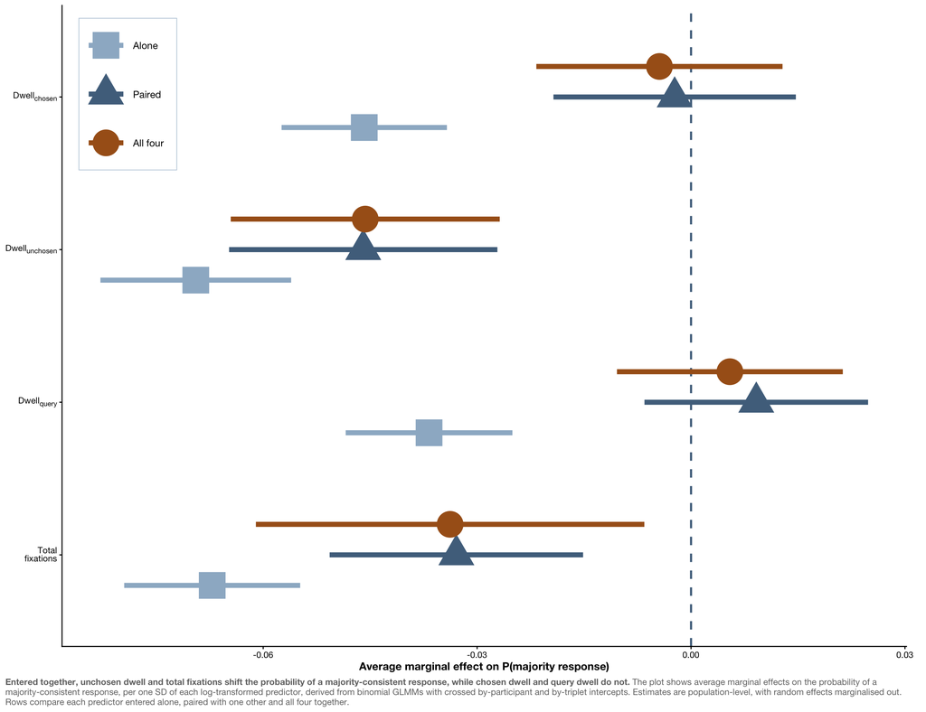

```r
# ---- Poster caption ----
prediction_finding <- sprintf(
  "**Entered together, %s %s the probability of a majority-consistent response%s.**",
  paste(
    sprintf("%s", pretty_terms[surv$term]),
    collapse = " and "
  ),
  if (nrow(surv) == 1L) "shifts" else "shift",
  if (nrow(gone) == 0L) {
    ""
  } else {
    sprintf(", while %s do not", paste(pretty_terms[gone$term], collapse = " and "))
  }
)

prediction_how <- paste(
  "The plot shows average marginal effects on the probability of a majority-consistent response, per one SD of each log-transformed predictor,",
  "derived from binomial GLMMs with crossed by-participant and by-triplet intercepts. Estimates are population-level, with random effects marginalised out.",
  "Rows compare each predictor entered alone, paired with one other and all four together."
)

# ---- Plotting proper ----
p_r3c2_prediction <-
  ame_all |>
  ggplot() +
  aes(
    x = estimate,
    y = facet,
    xmin = conf.low,
    xmax = conf.high,
    colour = model,
    shape = model
  ) +
  geom_vline(
    xintercept = 0,
    linetype = "dashed",
    colour = COL_NULL,
    linewidth = 0.5 * LWD
  ) +
  geom_pointrange(
    size = 1.5 * ANN,
    linewidth = 1.2 * LWD,
    position = position_dodge(width = 0.6)
  ) +
  scale_colour_manual(values = model_pal) +
  scale_shape_manual(values = model_shape) +
  labs(
    x = "Average marginal effect on P(majority response)",
    y = NULL,
    colour = NULL,
    shape = NULL
  ) +
  poster_text(
    prediction_finding,
    prediction_how
  ) +
  theme(
    legend.position = "inside",
    legend.position.inside = c(0.02, 0.98),
    legend.justification = c(0, 1),
    legend.key.height = unit(4 * FIG_BASE, "pt"),
    legend.key.width = unit(4 * FIG_BASE, "pt"),
    legend.key.spacing.y = unit(0.5 * FIG_BASE, "pt"),
    legend.margin = margin(
      t = 0.5 * FIG_BASE,
      r = 1.2 * FIG_BASE,
      b = 0.5 * FIG_BASE,
      l = 0.5 * FIG_BASE
    ),
    axis.text.y = ggtext::element_markdown(),
    plot.margin = margin(
      t = 0.5 * FIG_BASE,
      r = 1.8 * FIG_BASE,
      b = 0.5 * FIG_BASE,
      l = 0.5 * FIG_BASE
    )
  )

p_r3c2_prediction
```

## 6.4 Summary

With all four IVs entered together, unchosen dwell and total fixations retain an effect, while chosen dwell and query dwell have intervals overlapping zero. Chosen and query dwell do predict response in isolation. However, these associations are attributable to shared variance with how much the trial was scanned overall.

The substantive point is the asymmetry. Time on the option that was **not** chosen is the stronger trial-level predictor. Gaze in this task appears more tightly coupled to evidence *against* the rejected reference than to evidence *for* the selected one.

# 7 · Export

```r
theme_set(poster_theme(base_size = 22))

poster_blocks <- tibble::tribble(
  ~id,               ~object,               ~aspect,
  "r1c2-task",       "p_r1c2_task",         ASPECT_TASK,
  "r2c1-difficulty", "p_r2c1_difficulty",   ASPECT_RESULT,
  "r2c2-measures",   "p_r2c2_measures",     ASPECT_RESULT,
  "r3c1-cascade",    "p_r3c1_cascade",      ASPECT_RESULT,
  "r3c2-prediction", "p_r3c2_prediction",   ASPECT_RESULT
)

if (PUBLIC_BUILD) {
  message("Public build: panel export skipped, panels left untouched.")
} else {
  dir.create(
    OUT_DIR,
    showWarnings = FALSE,
    recursive = TRUE
  )
  pwalk(poster_blocks, \(id, object, aspect) {
    ggsave(
      filename = file.path(OUT_DIR, paste0(id, ".png")),
      plot = get(object),
      width = aspect * PANEL_H_MM,
      height = PANEL_H_MM,
      units = "mm",
      dpi = 300,
      bg = "white"
    )
  })
}

theme_set(poster_theme())  # restore for the rest of the document
```

[^1]: Note that this coding creates a lower bound on the dependent variable. Because the majority is defined per triplet, P(majority response) is bounded below at 0.5 by construction, which is why the panel reports average marginal effects of single predictors but omits the model’s classification accuracy.